# Analyse des Taux des Bons du Trésor à 10 Ans

## Transformation logarithmique

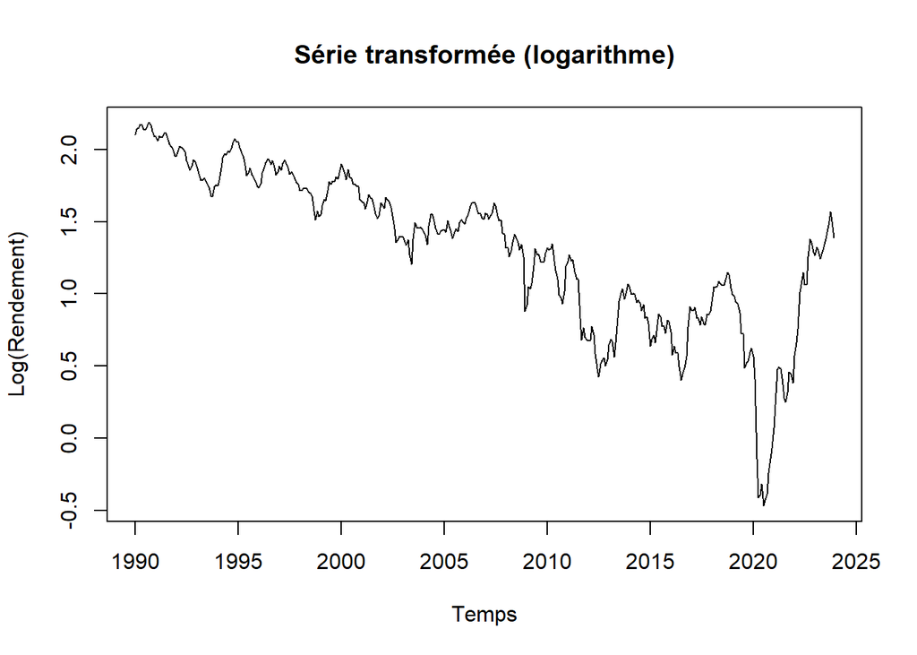

```r
log_ts_data <- log(ts_data_mensuelle)
plot(log_ts_data, main = "Série transformée (logarithme)", ylab = "Log(Rendement)", xlab = "Temps")
```

#Modèles ETS (Error, Trend, Seasonality)

## Modèle Holt-Winters avec formulation additive

```r
hw_add_model <- hw(ts_data_mensuelle, seasonal = "additive", h = 100)
summary(hw_add_model)
```

```
##
## Forecast method: Holt-Winters' additive method
##
## Model Information:
## Holt-Winters' additive method
##
## Call:
## hw(y = ts_data_mensuelle, h = 100, seasonal = "additive")
##
##   Smoothing parameters:
##     alpha = 0.9844
##     beta  = 1e-04
##     gamma = 0.0156
##
##   Initial states:
##     l = 8.4913
##     b = -0.0103
##     s = -0.0387 0.0536 -0.0019 -0.0186 -0.0027 0.0275
##            0.0379 0.0757 0.0225 -0.0604 -0.0704 -0.0245
##
##   sigma:  0.2247
##
##      AIC     AICc      BIC
## 1251.966 1253.535 1320.157
##
## Error measures:
##                         ME     RMSE       MAE        MPE     MAPE      MASE
## Training set -0.0003629607 0.220242 0.1705759 -0.1188985 5.106242 0.2269558
##                   ACF1
## Training set 0.2776186
##
## Forecasts:
##          Point Forecast     Lo 80    Hi 80       Lo 95    Hi 95
## Jan 2024       4.003587 3.7156326 4.291541  3.56319896 4.443975
## Feb 2024       3.977313 3.5732314 4.381395  3.35932338 4.595303
## Mar 2024       3.965085 3.4714622 4.458708  3.21015405 4.720016
## Apr 2024       4.014370 3.4451059 4.583634  3.14375576 4.884984
## May 2024       4.056891 3.4209066 4.692876  3.08423670 5.029545
## Jun 2024       4.025642 3.3292892 4.721996  2.96066207 5.090623
## Jul 2024       3.985965 3.2340633 4.737867  2.83603059 5.135899
```

[output cut: 78 more lines]

```
## Feb 2031       3.107763 0.4635446 5.751982 -0.93622007 7.151746
## Mar 2031       3.095535 0.4358949 5.755175 -0.97203343 7.163103
## Apr 2031       3.144820 0.4698442 5.819795 -0.94620240 7.235842
## May 2031       3.187341 0.4971139 5.877568 -0.92700628 7.301688
## Jun 2031       3.156092 0.4506967 5.861488 -0.98145323 7.293638
## Jul 2031       3.116415 0.3959321 5.836897 -1.04420446 7.277034
## Aug 2031       3.064407 0.3289178 5.799897 -1.11916299 7.247978
## Sep 2031       3.047929 0.2975110 5.798347 -1.15847227 7.254330
## Oct 2031       3.069510 0.3042417 5.834779 -1.15960303 7.298623
## Nov 2031       3.086716 0.3066735 5.866759 -1.16499226 7.338425
## Dec 2031       3.020040 0.2252981 5.814782 -1.25414894 7.294229
## Jan 2032       3.009815 0.1999860 5.819644 -1.28744767 7.307078
## Feb 2032       2.983542 0.1591623 5.807921 -1.33597382 7.303057
## Mar 2032       2.971313 0.1324554 5.810171 -1.37034525 7.312972
## Apr 2032       3.020598 0.1673322 5.873864 -1.34309560 7.384292
```

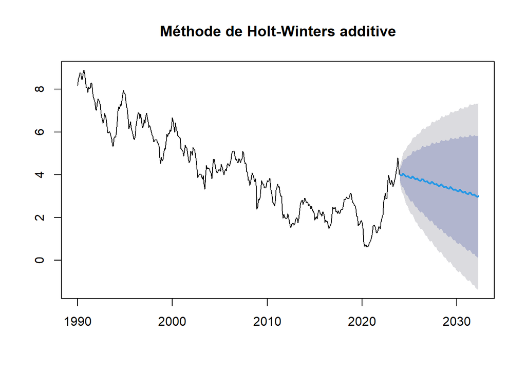

```r
plot(hw_add_model, main = "Méthode de Holt-Winters additive")
```

## Modèle Holt-Winters avec formulation multiplicative

```r
hw_mult_model <- hw(ts_data_mensuelle, seasonal = "multiplicative", h = 100)
summary(hw_mult_model)
```

```
##
## Forecast method: Holt-Winters' multiplicative method
##
## Model Information:
## Holt-Winters' multiplicative method
##
## Call:
## hw(y = ts_data_mensuelle, h = 100, seasonal = "multiplicative")
##
##   Smoothing parameters:
##     alpha = 0.9883
##     beta  = 1e-04
##     gamma = 0.0117
##
##   Initial states:
##     l = 8.6732
##     b = -0.0103
##     s = 0.973 0.9796 0.9837 0.981 0.9911 1.0105
##            1.0246 1.0317 1.0239 1.0156 0.9947 0.9905
##
##   sigma:  0.0733
##
##      AIC     AICc      BIC
## 1410.813 1412.382 1479.004
##
## Error measures:
##                         ME      RMSE       MAE        MPE     MAPE      MASE
## Training set -0.0006303117 0.2191642 0.1692622 -0.1277501 5.005568 0.2252079
##                   ACF1
## Training set 0.2748809
##
## Forecasts:
##          Point Forecast       Lo 80    Hi 80       Lo 95    Hi 95
## Jan 2024       4.057745  3.67666402 4.438826  3.47493198 4.640558
## Feb 2024       4.083380  3.54278630 4.623974  3.25661316 4.910147
## Mar 2024       4.134684  3.46382563 4.805543  3.10869450 5.160674
## Apr 2024       4.168872  3.38653001 4.951215  2.97238292 5.365362
## May 2024       4.200953  3.31771928 5.084187  2.85016347 5.551743
## Jun 2024       4.167184  3.20525049 5.129118  2.69603359 5.638335
## Jul 2024       4.091179  3.06868481 5.113674  2.52740890 5.654950
```

[output cut: 78 more lines]

```
## Feb 2031       3.220599 -0.37598297 6.817180 -2.27989829 8.721096
## Mar 2031       3.258851 -0.41450870 6.932211 -2.35906784 8.876770
## Apr 2031       3.283556 -0.45209515 7.019207 -2.42962936 8.996741
## May 2031       3.306554 -0.49007715 7.103185 -2.49989220 9.113000
## Jun 2031       3.277711 -0.52044655 7.075869 -2.53106975 9.086492
## Jul 2031       3.215696 -0.54472166 6.976114 -2.53536652 8.966758
## Aug 2031       3.144166 -0.56610157 6.854434 -2.53019880 8.818532
## Sep 2031       3.112677 -0.59372854 6.819083 -2.55578117 8.781135
## Oct 2031       3.118165 -0.62826953 6.864600 -2.61151240 8.847843
## Nov 2031       3.092548 -0.65646773 6.841563 -2.64107659 8.826172
## Dec 2031       3.049540 -0.68037624 6.779456 -2.65487451 8.753954
## Jan 2032       3.080338 -0.72131347 6.881990 -2.73378626 8.894463
## Feb 2032       3.097315 -0.75914064 6.953770 -2.80062480 8.995254
## Mar 2032       3.133702 -0.80246422 7.069868 -2.88614474 9.153549
## Apr 2032       3.157052 -0.84326519 7.157369 -2.96090511 9.275009
```

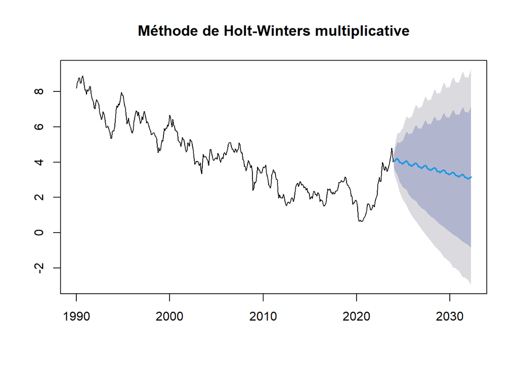

```r
plot(hw_mult_model, main = "Méthode de Holt-Winters multiplicative")
```

## Appliquer un modèle ETS automatique

```r
ets_model <- ets(ts_data_mensuelle)
summary(ets_model)
```

```
## ETS(A,Ad,N)
##
## Call:
## ets(y = ts_data_mensuelle)
##
##   Smoothing parameters:
##     alpha = 0.9998
##     beta  = 0.155
##     phi   = 0.8
##
##   Initial states:
##     l = 8.0729
##     b = 0.1896
##
##   sigma:  0.2192
##
##      AIC     AICc      BIC
## 1220.973 1221.183 1245.041
##
## Training set error measures:
##                        ME      RMSE       MAE        MPE     MAPE      MASE
## Training set -0.007603445 0.2178282 0.1707522 -0.2174241 5.058056 0.2271904
##                   ACF1
## Training set 0.1791429
```

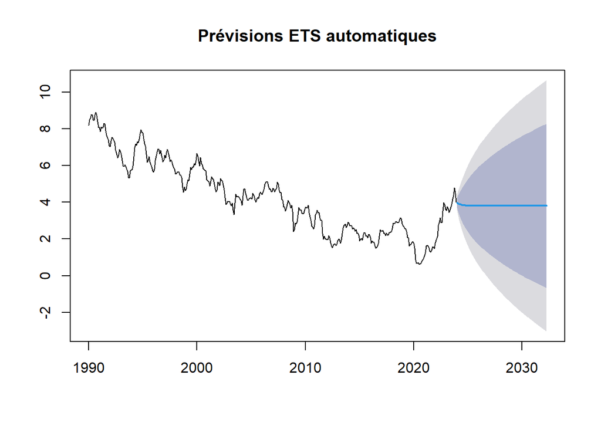

```r
plot(forecast(ets_model, h = 100), main = "Prévisions ETS automatiques")
```

Le modèle ETS(A,Ad,N) s’adapte bien aux données en prenant en compte une tendance qui ralentit avec le temps et les variations récentes, sans inclure de saisonnalité. Les prévisions indiquent une stabilisation des rendements des bons du Trésor à long terme. L’ajustement est précis, comme le montre une faible marge d’erreur, mais les intervalles de confiance qui s’élargissent montrent qu’il y a plus d’incertitudes pour les prévisions à long terme, surtout dans un contexte économique incertain.

## Créer un tableau de comparaison

```r
comparison_ets <- data.frame(
  Modèle = c("ETS Auto", "Holt-Winters Additif", "Holt-Winters Multiplicatif"),
  AIC = c(AIC(ets_model), AIC(hw_add_model$model), AIC(hw_mult_model$model)),
  RMSE = c(accuracy(ets_model)[2], accuracy(hw_add_model$model)[2], accuracy(hw_mult_model$model)[2])
)
print(comparison_ets)
```

```
##                       Modèle      AIC      RMSE
## 1                   ETS Auto 1220.973 0.2178282
## 2       Holt-Winters Additif 1251.966 0.2202420
## 3 Holt-Winters Multiplicatif 1410.813 0.2191642
```

Le modèle ETS Auto est le meilleur choix pour ces données, car il présente l’AIC le plus faible et une précision compétitive en termes de RMSE. Le modèle Holt-Winters Additif peut être une alternative viable, avec un RMSE similaire, mais un AIC légèrement supérieur. Le modèle Holt-Winters Multiplicatif est moins performant en raison de son AIC élevé, indiquant qu’il est moins adapté pour cette série temporelle spécifique.

## Prévision de séries chronologiques

# Autoregression (AR)

```r
ar_model <- ar(train_mensuelle)
ar_forecast <- predict(ar_model, n.ahead = length(test_mensuelle))
```

# Moving Average (MA)

```r
ma_model <- Arima(train_mensuelle, order = c(0, 0, 1))
ma_forecast <- forecast(ma_model, h = length(test_mensuelle))
```

# ARIMA

```r
auto_arima_model <- auto.arima(train_mensuelle, seasonal = TRUE)
forecast_arima <- forecast(auto_arima_model, h = length(test_mensuelle))
```

# SARIMA

```r
sarima_model <- auto.arima(train_mensuelle, seasonal = TRUE, stepwise = FALSE)
forecast_sarima <- forecast(sarima_model, h = length(test_mensuelle))
```

## Visualisation des prévisions

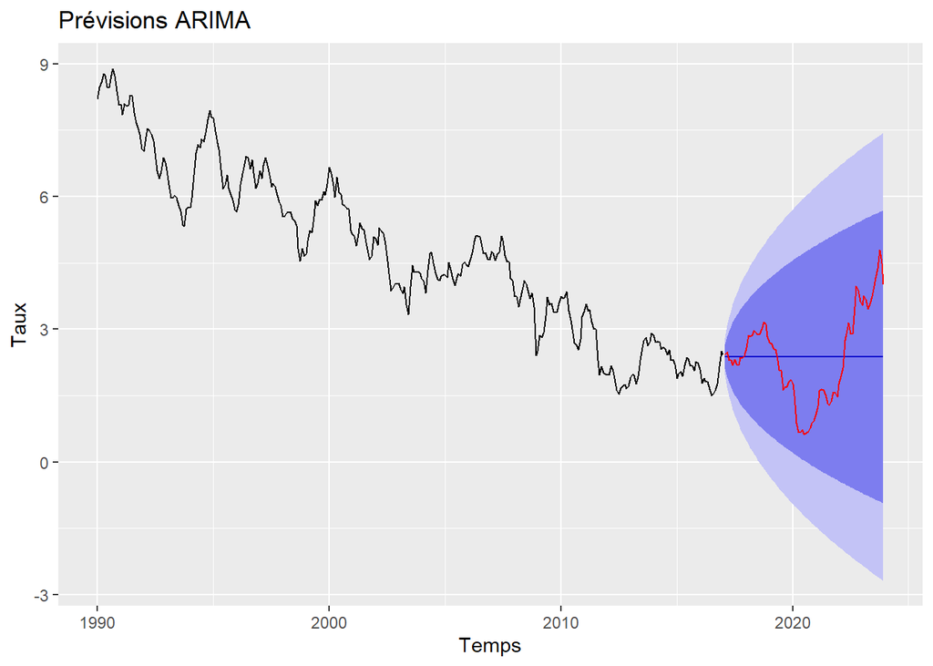

```r
autoplot(forecast_arima) +
  autolayer(test_mensuelle, series = "Test", color = "red") +
  labs(title = "Prévisions ARIMA", x = "Temps", y = "Taux")
```

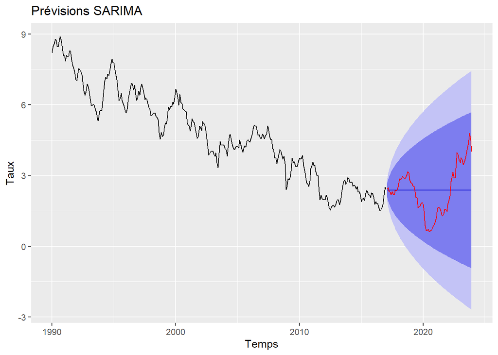

```r
autoplot(forecast_sarima) +
  autolayer(test_mensuelle, series = "Test", color = "red") +
  labs(title = "Prévisions SARIMA", x = "Temps", y = "Taux")
```

## Validation des résidus

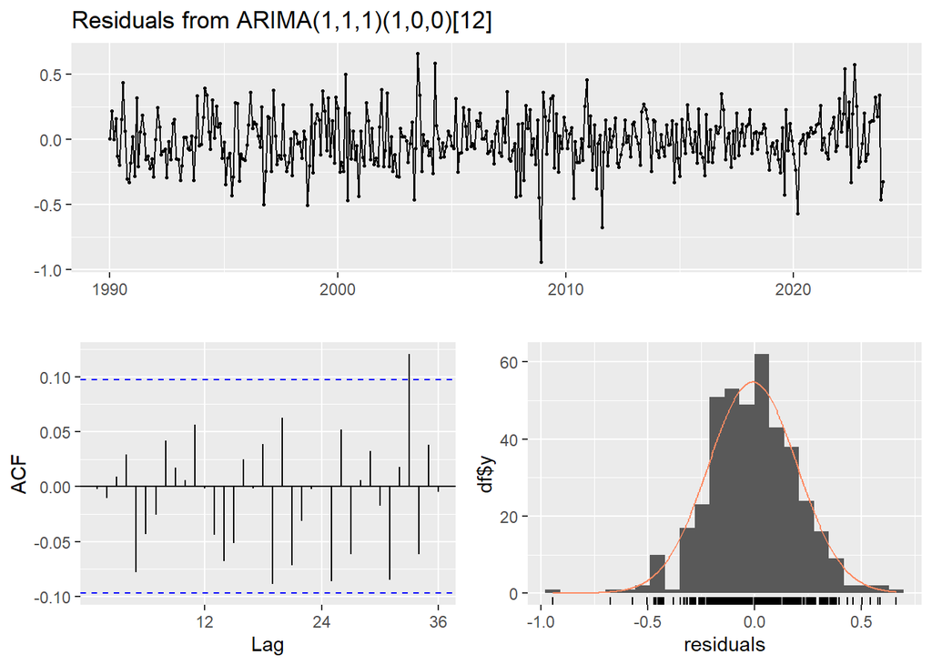

```
##
##  Ljung-Box test
##
## data:  Residuals from ARIMA(1,1,1)(1,0,0)[12]
## Q* = 18.76, df = 21, p-value = 0.6006
##
## Model df: 3.   Total lags used: 24
```

```r
checkresiduals(model_arima)
```

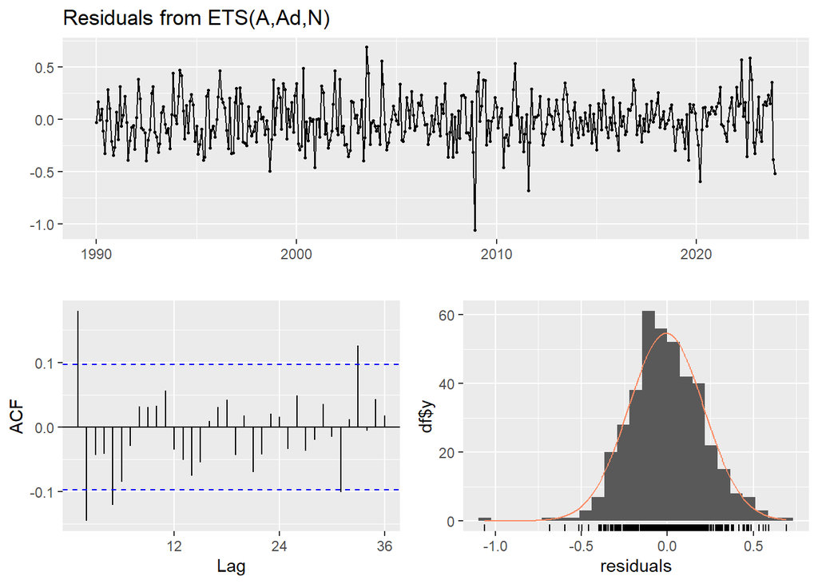

```
##
##  Ljung-Box test
##
## data:  Residuals from ETS(A,Ad,N)
## Q* = 46.031, df = 24, p-value = 0.004389
##
## Model df: 0.   Total lags used: 24
```

```r
checkresiduals(ets_model)
```

# Conclusion

Ce document a exploré et modélisé les taux des bons du Trésor à 10 ans, en utilisant divers modèles pour des prévisions robustes.